# Intake Form Analysis

Hume Dickie

December 10, 2017

Maybe make read the sheet id from a file just in case of disaster?

### Appointment Count Over Time For Each Semester

TODO save individual semester plots in a subfolder

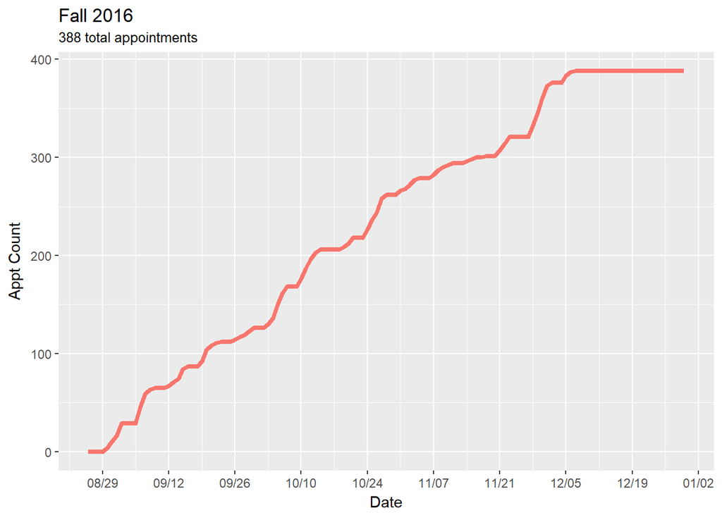

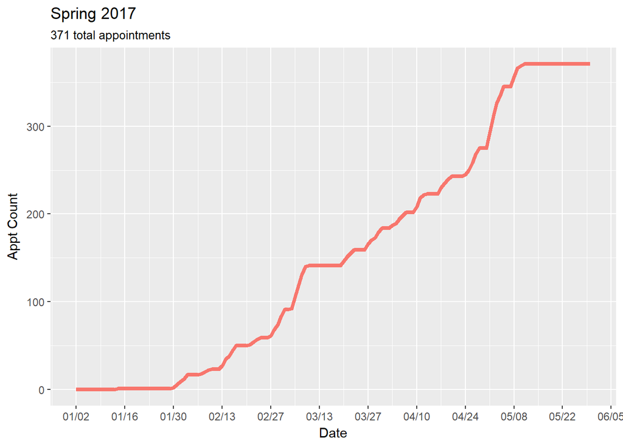

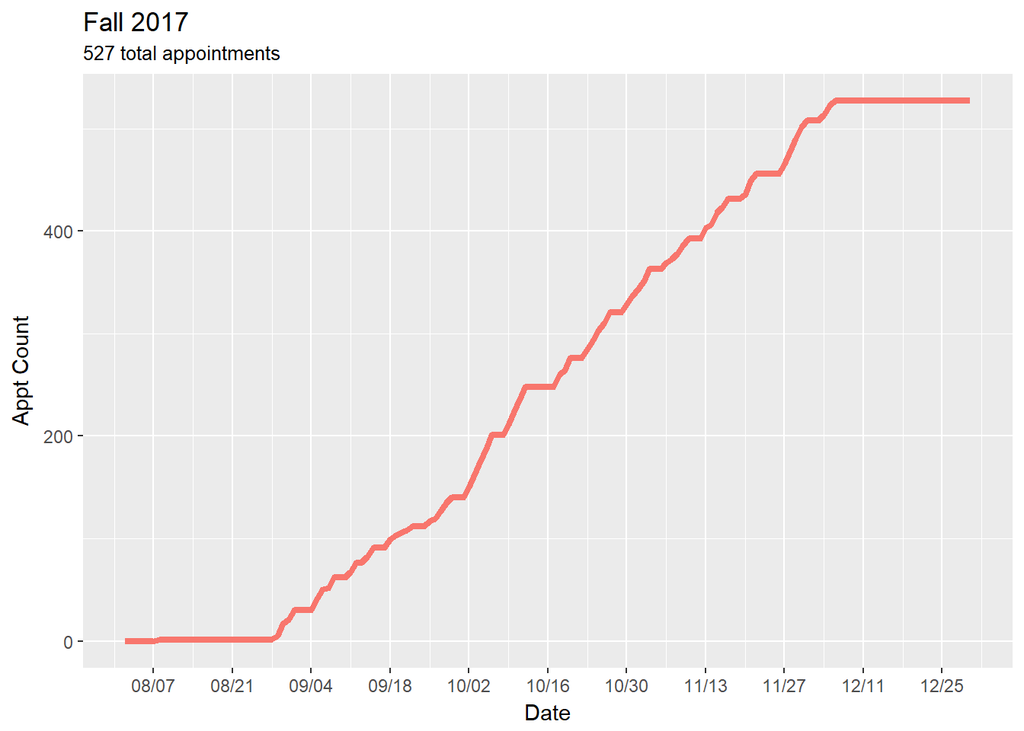

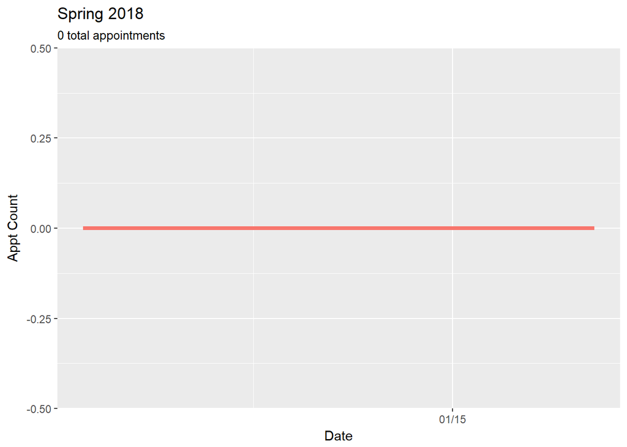

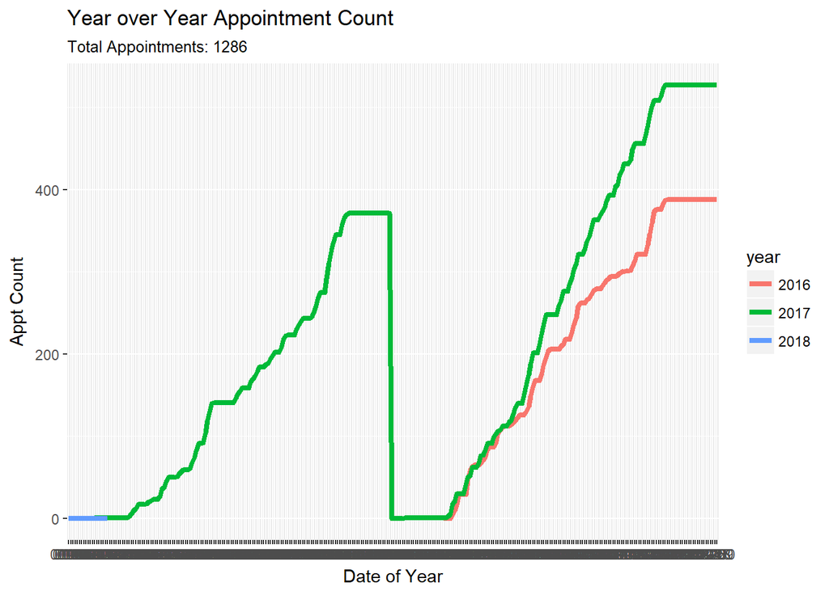

### Types of Assignments

```r
#instead of the distance from each other, use this method to get the distance from strings you know ahead of time should appear
getDistFromSetMatrix <- function(list.of.strings,known.strings) {
  unique.strings <- unique(list.of.strings %>% unlist())

  #defines an m x n matrix, where each column represents a known string
  m <- length(unique.strings)
  n <- length(known.strings)
  string.dist.matrix <- matrix(nrow=m,ncol=n)

  #for each row, compute dist from each known string
  for (i in 1:m) {
    for (j in 1:n) {
      dist <- stringdist(unique.strings[[i]],known.strings[[j]])
      string.dist.matrix[i,j] <- dist
    }
  }


  string.dist.matrix[is.na(string.dist.matrix)] <- 0
  string.dist.matrix <- string.dist.matrix %>% apply(2,as.integer)
  return(string.dist.matrix)
}
```

This is common types of assignments, but not how many people come in with assignments of this type

```
## [1] "-----------------------------------------------------"
##  [1] "introductory" "introduction" "impromptu"    "epideictic"
##  [5] "epidietic"    "epidiectic"   "leadership"   "epididemic"
##  [9] "epideitic"    "prepare for"  "credibility"  "proposition"
## [13] "introdutory"  "my passion"   "ec drop in"
## [1] "-----------------------------------------------------"
## [1] "informative"           "informative i"         "informative es"
## [4] "informational"         "informative concept"   "informative ii"
## [7] "informative slideshow" "informative outline"   "informative group"
## [1] "-----------------------------------------------------"
## [1] "whats name"    "praise blame"  "ethical case"  "virtues vices"
## [5] "culture paper" "policy paper"  "group sales"   "interview"
## [9] "final paper"
## [1] "-----------------------------------------------------"
## [1] "first assignment"         "collaborative assignment"
```

[output cut: 19 more lines]

```r
known.assignments <- c("persuasive","informative","rogerian","paper","essay","final","extemporaneous","outline","comemmorative","culture","definition","first","group","introduction","memorize","problem solution","proposal","research","special occasion","storytelling","life story","praise blame","toefl","significant life story","research paper","significant life","epideictic","memorization","essay outline","final draft","oral interpretation","debate","final paper")

dist.from.known.assignments <- getDistFromSetMatrix(unique.assignments,known.assignments)

pretty.close <- which(dist.from.known.assignments <= 4)
near.match <- (pretty.close/length(unique.assignments)) %>% ceiling()
input.assignment  <- pretty.close %% length(unique.assignments)

unique.assignments[input.assignment]
```

```
##   [1] "my persuasive"            "persuasive"
##   [3] "persuasion"               "persuaive"
##   [5] "nd persuasive"            "informative"
##   [7] "narrative"                "informative i"
##   [9] "informative es"           "informational"
##  [11] "informative ii"           "rogerian"
##  [13] "rogarian"                 "name"
##  [15] "names"                    "praise"
##  [17] "paper"                    "honor"
##  [19] "none"                     "gender"
##  [21] "art"                      "chapter"
##  [23] "video"                    "team"
##  [25] "class"                    "for essay"
##  [27] "final"                    "essay"
##  [29] "essay for"                "eulogy"
```

[output cut: 42 more lines]

```r
unmatched <- rep(TRUE,length(unique.assignments))
unmatched[input.assignment] <- FALSE

unique.assignments[unmatched]
```

```
##   [1] "objective"
##   [2] "show favorite"
##   [3] "pet peeves"
##   [4] "impromptu"
##   [5] "personal life story"
##   [6] "pet peeve"
##   [7] "object that has contributed person you are today"
##   [8] "whats name"
##   [9] "object that has helped shape you into person you are today"
##  [10] "significant moment"
##  [11] "my favorite"
##  [12] "toefl exam"
##  [13] "occasional"
##  [14] "informative object event"
##  [15] "social occasion presntation"
```

[output cut: 218 more lines]

### Professors

Let’s do substring matches searching for last names only! String distance from split on space! If one of them is super low call it a match!

Angela Beasley Beste Yuksel Cynthia Shultes Deborah Callister Eric Christiansen Gina Stahlricco Jacquelyn Horton Leigh Meredith Lindsey Ayotte Lynn Perkins Maximilian Delaure Michael Rozendal Patricia Kalman Suzanne Pullens

```r
#usf.professors <- c("hunt","horton","delore","delaure","beasly","callister","christian","ricco","rosendahl","ayotte","perkins","pullen","beasley","martin","meredith","sullivan","rozendal","beasely","yuksel","rosendal","stahl","kalman","gina","stahlricco","schultes","suzanne","cynthia")

usf.professors <- c("angela","beasley","beste","yuksel","cynthia","shultes","deborah","callister","eric","christiansen","gina","stahlricco","jacquelyn","horton","leigh","meredith","lindsey","ayotte","lynn","perkins","maximilian","delaure","michael","rozendal","patricia","kalman","suzanne","pullens")

unmatched.profs <- rep(TRUE,length(unique.profs))
mapped.profs <- rep("",length(unique.profs))
for(i in 1:length(unique.profs)) {
  for(professor in usf.professors) {
    #print(paste(professor," in ",unique.profs[[i]],"?",sep=""))
    if (grepl(professor,unique.profs[[i]])) {
      unmatched.profs[[i]] <- FALSE
      mapped.profs[[i]] <- professor
    }
  }
}

#unmatched and has a space in it
unique.profs[unmatched.profs & (lapply(unique.profs,grepl,pattern=" ") %>% unlist())] %>% sort()
```

```
##  [1] "alesandra casar"    "arnolfo kathleen a" "ben linzer"
##  [4] "cathy kabor"        "christian thompson" "daniel husman"
##  [7] "david batstone"     "david holler"       "devon c holmes"
## [10] "devon holmes"       "did not know"       "dr marc martin"
## [13] "dr popal"           "dr popao"           "dr schultes"
## [16] "erik christianson"  "gonzales howell"    "how to"
## [19] "james boyd"         "joanne babin"       "john hunt"
## [22] "john ryan"          "johnathan hunt"     "jonathan hunt"
## [25] "jonathon hunt"      "kathy gaber"        "lee merideth"
## [28] "leslie dennen"      "lin wan"            "marc martin"
## [31] "mare alalise"       "mark martin"        "marla loenthal"
## [34] "marla lorenthal"    "marla louenthal"    "max delore"
## [37] "max delure"         "mcclure baker"      "mr boller"
## [40] "mr hunt"            "nic tay"            "nichole brodsky"
## [43] "nicole brodsky"     "nicole howell"      "patrick mcdonald"
## [46] "patrick mcdonnell"  "paula birnbaun"     "pro schultes"
## [49] "pro schutles"       "richard lindsay"    "rick robert"
## [52] "rick roberts"       "rick rorbert"       "robert boller"
## [55] "robert bowler"      "robert boyle"       "robert r boller"
## [58] "sabrina nelson"     "shannon siegel"     "stahl haven"
## [61] "stahl rico"         "sthal haven"        "susan pullen"
## [64] "suznne pullen"      "suzzanne pullin"    "tika lamsal"
## [67] "todd slingsby"      "ursala aldana"      "wan liu"
```

```r
#same length as unique.rpfs, but every element is here a list of one or more strings
for(i in 1:length(unique.profs)) {
  splitname <- strsplit(unique.profs[[i]]," ")
  for (partialname in splitname) {
    if(!unmatched.profs[[i]]){
      next
    }

    dist.from.each.prof <- getDistFromSetMatrix(usf.professors,partialname)

    near.matches.indices <- which(dist.from.each.prof <= 3) %% length(usf.professors) %>% unique()
    mapped.profs[[i]] <- usf.professors[near.matches.indices] %>% list()

    if(length(mapped.profs) > 0) {
      unmatched.profs[[i]] <- FALSE
    }
  }
}

unique.profs[unmatched.profs]
```

```
## character(0)
```

```
## [1] "-----------------------------------------------------"
##  [1] "angela beasley"  "richard lindsay" "marc martin"
##  [4] "rick roberts"    "susan pullen"    "joanne babin"
##  [7] "sabrina nelson"  "dr marc martin"  "paula birnbaun"
## [10] "tika lamsal"     "kathy gaber"     "suznne pullen"
## [13] "angela beasely"  "patricia kalman" "mrs kalman"
## [16] "mare alalise"    "rick robert"     "lynn perkins"
## [19] "robert boller"   "rick rorbert"    "ursala aldana"
## [22] "maximillian"     "nicole brodsky"  "nichole brodsky"
## [25] "robert bowler"   "robert r boller" "patricia kalmin"
## [28] "robert boyle"    "petra kalman"    "mark martin"
## [31] "suzanne pullen"  "lindsey perkins" "cathy kabor"
## [34] "daniel husman"   "lynne perkins"   "todd slingsby"
## [37] "mcclurebaker"    "mcclure baker"   "suzanne pollen"
## [40] "suzzanne pullin" "james boyd"      "shannon siegel"
```

[output cut: 31 more lines]

### Classes

This is common types of classes, but not how many people come in with assignments of this type

```
## [1] "-----------------------------------------------------"
##  [1] "first year seminar: bicycles"
##  [2] "graduate speaking writing program"
##  [3] "graduate speaking and writing"
##  [4] "som - group presentation bus"
##  [5] "business technical writing"
##  [6] "cs 686 - human computer interaction"
##  [7] "first year seminar- speaking of bicycles"
##  [8] "human computer interaction cs486"
##  [9] "human computer science"
## [10] "human computer interaction"
## [11] "written and oral communication (rhet 131)"
## [12] "rhet 310: business and technical writing"
## [13] "commencement speaker - graduate college of a and s"
## [14] "preparation and evaluation of tesol materials"
## [15] "general speaking english education"
## [16] "first year seminar speaking of bicycles"
## [17] "assessment and testing of second language proficiency"
## [18] "service learning 304: organizational behavior management"
## [19] "business and technical writing"
```

### Sign Up Method & Extra Credit/Required

TODO over time

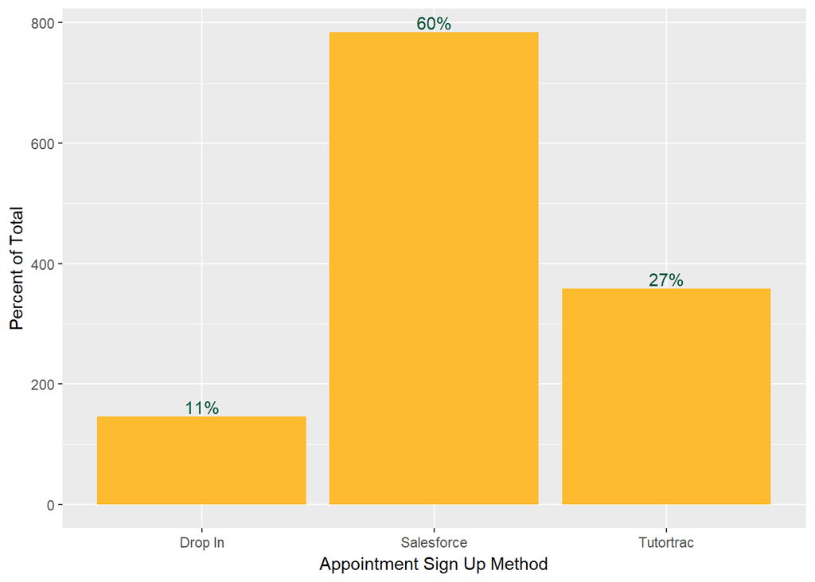

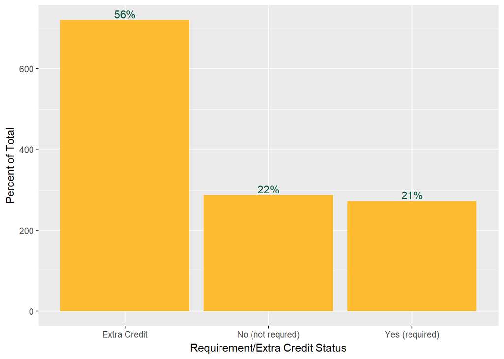

### Unique and Returning Students